# Homework 10

Vaishnavi Maganti

2026-02-11

## Instructions

Answer the following questions and complete the exercises in RMarkdown. Please embed all of your code and push your final work to your repository. Your final lab report should be organized, clean, and run free from errors. Remember, you must remove the `#` for the included code chunks to run. Be sure to add your name to the author header above.

Make sure to use the formatting conventions of RMarkdown to make your report neat and clean!

## Background

In the `data` folder, you will find data about shark incidents in California between 1950-2022. The [data](https://catalog.data.gov/dataset/shark-incident-database-california-56167) are from: State of California- Shark Incident Database.

## Load the libraries

```r
library("tidyverse")
library("janitor")
```

## Load the data

Run the following code chunk to import the data. In this chunk, I am removing NA’s.

```r
sharks <-
  read_csv("data/SharkIncidents_1950_2022_220302.csv",
           na=c("NA", "N/A", "Unknown", "NOT COUNTED", "", " ")) %>%
  clean_names()
```

## Questions

```r
names(sharks)
```

```
##  [1] "incident_num"     "month"            "day"              "year"
##  [5] "time"             "county"           "location"         "mode"
##  [9] "injury"           "depth"            "species"          "comment"
## [13] "longitude"        "latitude"         "confirmed_source" "wfl_case_number"
```

```r
sharks
```

```
## # A tibble: 211 × 16
##    incident_num month   day  year time  county       location mode  injury depth
##           <dbl> <dbl> <dbl> <dbl> <chr> <chr>        <chr>    <chr> <chr>  <chr>
##  1            1    10     8  1950 12:00 San Diego    Imperia… Swim… major  surf…
##  2            2     5    27  1952 14:00 San Diego    Imperia… Swim… minor  surf…
##  3            3    12     7  1952 14:00 Monterey     Lovers … Swim… fatal  surf…
##  4            4     2     6  1955 12:00 Monterey     Pacific… Free… minor  surf…
##  5            5     8    14  1956 16:30 San Luis Ob… Pismo B… Swim… major  surf…
##  6            6     4    28  1957 13:30 San Luis Ob… Morro B… Swim… fatal  surf…
##  7            7    10    12  1958 <NA>  San Diego    Coronad… Swim… major  surf…
##  8            8     5     7  1959 17:30 San Francis… Baker B… Swim… fatal  surf…
##  9            9     6    14  1959 17:00 San Diego    La Jolla Free… fatal  surf…
## 10           10     7    28  1959 19:30 San Diego    La Jolla Free… minor  surf…
## # ℹ 201 more rows
## # ℹ 6 more variables: species <chr>, comment <chr>, longitude <chr>,
## #   latitude <dbl>, confirmed_source <chr>, wfl_case_number <chr>
```

1. Are there any “hotspots” for shark incidents in California? Show the top five counties with the most incidents.

```r
sharks %>%
  select(county) %>%
    group_by(county) %>%
  count(county) %>%
  summarize(across(where(is.numeric), ~sum(.x, na.rm=T))) %>%
  arrange(desc(n)) %>%
   slice_head(n=5)
```

```
## # A tibble: 5 × 2
##   county            n
##   <chr>         <int>
## 1 San Diego        25
## 2 Humboldt         20
## 3 San Mateo        19
## 4 Santa Barbara    19
## 5 Marin            16
```

The top 5 counties/“hotspots” with the most incidents are San Diego, Humboldt, San Mateo, Santa Barbara, and Marin county.

2. Make a plot that shows the total number of incidents per county.

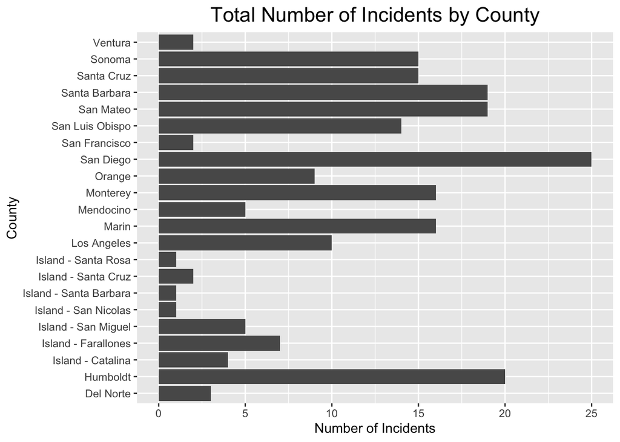

```r
sharks %>%
ggplot(aes(x=county)) +
  geom_bar()+
  coord_flip() +
  labs(title="Total Number of Incidents by County", x="County", y = "Number of Incidents") +
    theme(plot.title=element_text(size=rel(1.5), hjust = 0.5))
```

3. Are there months of the year when incidents are more likely to occur? Make a plot that shows the total number of incidents by month. Which month has the highest number of incidents?

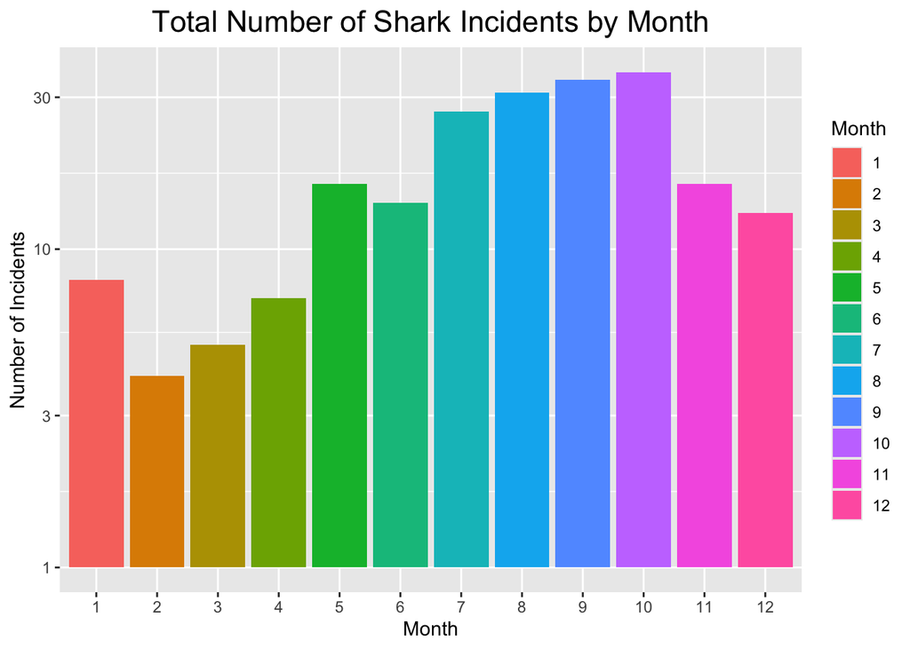

```r
sharks %>%
ggplot(aes(x= as.factor(month))) +
  geom_bar(aes(fill= as.factor(month)))+
  labs(title="Total Number of Shark Incidents by Month", x="Month", y = "Number of Incidents", fill = "Month") +
  theme(plot.title=element_text(size=rel(1.5), hjust = 0.5)) +
  scale_y_log10()
```

Month 10 has the highest number of shark attack incidents, so the month of October. Incidents are more likely to occur around month 7 to month 10, so around July to October.

4. Is there a time of day when most attacks occur? Make a plot that shows the total number of incidents by time of day. Which time of day has the highest number of incidents?

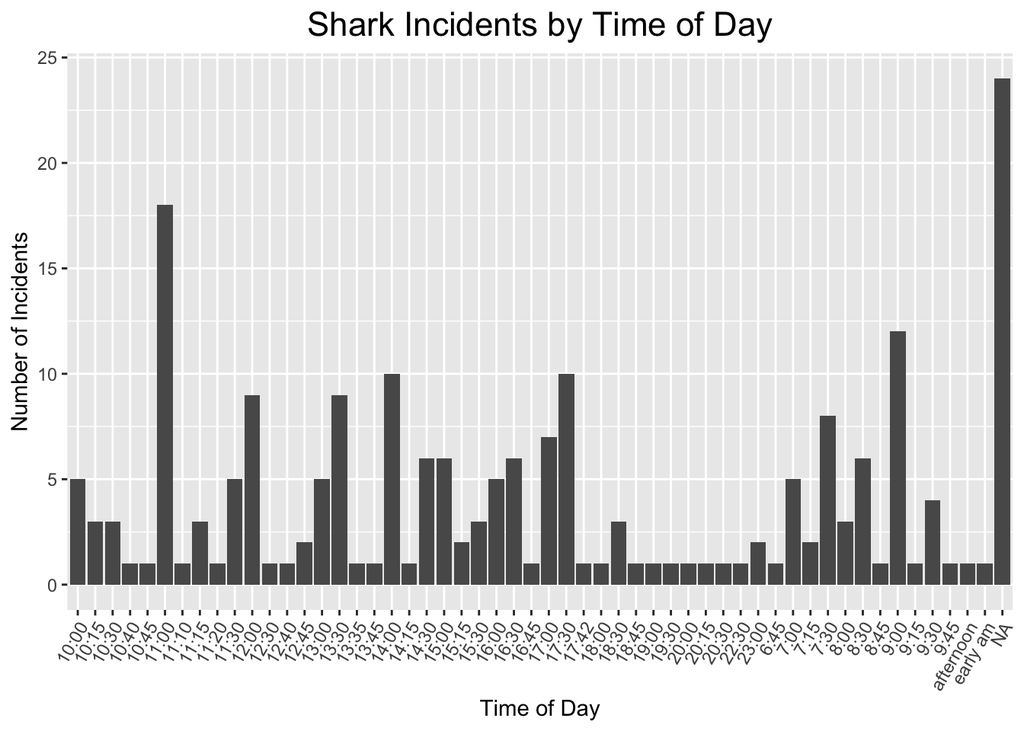

```r
sharks %>%
  ggplot(aes(x=time)) +
  geom_bar(na.rm = T)+
  labs(title = "Shark Incidents by Time of Day", x = "Time of Day", y = "Number of Incidents") +
  theme(plot.title=element_text(size=rel(1.5), hjust = 0.5)) +
  theme(axis.text.x = element_text(angle=60, hjust = 1))
```

11:00 A.M. is the time of day with the highest number of incidents.

5. How do the number and types of injuries compare by county? Make a table that shows the number of injury types by county. Which county has the highest number incidents? (hint: your table should be in wide format)

```r
injury_table <- sharks %>%
  count(county, injury) %>%
  pivot_wider(
    names_from = injury,
    values_from = n,
    values_fill = 0
  )
injury_table
```

```
## # A tibble: 22 × 8
##    county                 minor  none major `minor*` `none*` fatal `major*`
##    <chr>                  <int> <int> <int>    <int>   <int> <int>    <int>
##  1 Del Norte                  2     1     0        0       0     0        0
##  2 Humboldt                   2     9     7        1       1     0        0
##  3 Island - Catalina          1     3     0        0       0     0        0
##  4 Island - Farallones        0     0     7        0       0     0        0
##  5 Island - San Miguel        2     0     2        0       0     1        0
##  6 Island - San Nicolas       1     0     0        0       0     0        0
##  7 Island - Santa Barbara     0     0     0        0       0     0        1
##  8 Island - Santa Cruz        1     1     0        0       0     0        0
##  9 Island - Santa Rosa        0     0     1        0       0     0        0
## 10 Los Angeles                6     2     0        0       0     1        1
## # ℹ 12 more rows
```

```r
sharks %>%
  count(county, sort = T) %>%
  slice_head(n=1)
```

```
## # A tibble: 1 × 2
##   county        n
##   <chr>     <int>
## 1 San Diego    25
```

The county with the highest number of incidents is San Diego county.

6. Use the table from #5 to make a plot that shows the total number of incidents by county.

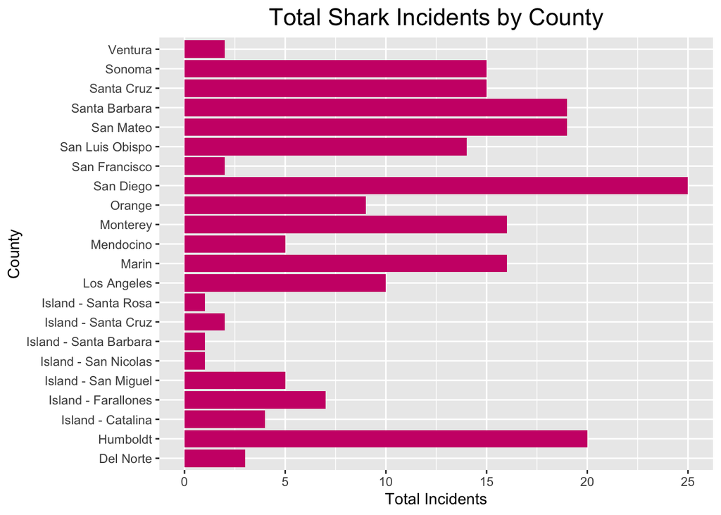

```r
injury_table %>%
  mutate(total_incidents = minor + `none` + major + `minor*` + `none*` + fatal + `major*`) %>%
  ggplot(aes(x=county, y = total_incidents)) +
  geom_col(fill = "deeppink3", na.rm = T) +
  coord_flip() +
  labs(title = "Total Shark Incidents by County", x = "County", y = "Total Incidents")+
   theme(plot.title=element_text(size=rel(1.5), hjust = 0.5))
```

7. In the data, `mode` refers to a type of activity. Which activity is associated with the highest number of incidents?

```r
sharks %>%
  count(mode, sort = T) %>%
  slice_head(n=1)
```

```
## # A tibble: 1 × 2
##   mode                   n
##   <chr>              <int>
## 1 Surfing / Boarding    85
```

Surfing/Boarding is associated with the highest number of incidents.

8. Make a plot that compares the number of incidents by activity.

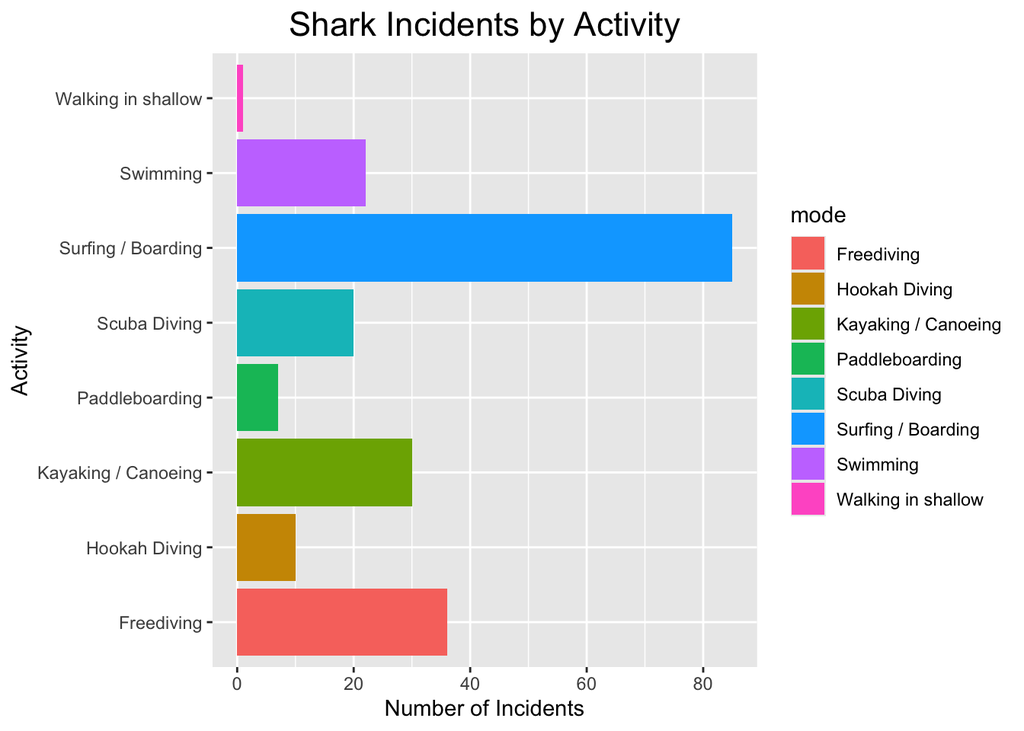

```r
activity_counts <- sharks %>%
  group_by(mode) %>%
  summarize(total_incidents = n()) %>%
  ggplot(aes(x = mode, y = total_incidents)) +
  geom_col(aes(fill=mode)) +
  coord_flip() +
  labs(title = "Shark Incidents by Activity", x = "Activity", y = "Number of Incidents") +
  theme(plot.title=element_text(size=rel(1.5), hjust = 0.5))
activity_counts
```

9. Which shark species is involved in the highest number of incidents?

```r
sharks %>%
  count(species, sort = T) %>%
slice_head(n=1)
```

```
## # A tibble: 1 × 2
##   species     n
##   <chr>   <int>
## 1 White     181
```

The Great White Shark is involved in the highest number of incidents.

10. Are all incidents involving Great White’s fatal? Make a plot that shows the number and types of incidents for Great White’s only.

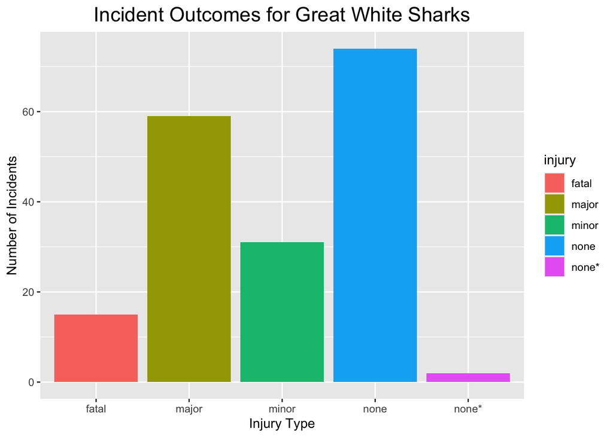

```r
great_white <- sharks %>%
  filter(species == "White") %>%
  ggplot(aes(x=injury)) +
  geom_bar(aes(fill = injury)) +
  labs(title = "Incident Outcomes for Great White Sharks", x = "Injury Type", y = "Number of Incidents") +
  theme(plot.title=element_text(size=rel(1.5), hjust = 0.5))
great_white
```

No, not all incidents are fatal. They are mostly major, or even no injuries.

## Knit and Upload

Please knit your work as an .html file and upload to Canvas. Homework is due before the start of the next lab. No late work is accepted. Make sure to use the formatting conventions of RMarkdown to make your report neat and clean!